# Final Project

2023-11-30

# Data Documentation

## 1. Link for each datasets

- Healthcare5Years: This is the link for 2022 setting, got each year data then merged (2022 2021 2019 2018 2017)  
  https://data.census.gov/mdat/#/search?ds=ACSPUMS1Y2022&vv=PERNP&cv=HICOV&rv=ucgid&wt=PWGTP&g=0400000US01,02,04,05,06,08,09,10,11,12,13,15,16,17,18,19,20,21,22,23,24,25,26,27,28,29,30,31,32,33,34,35,36,37,38,39,40,41,42,44,45,46,47,48,49,50,51,53,54,55,56
- SNAP2022Race  
  https://data.census.gov/mdat/#/search?ds=ACSPUMS1Y2022&cv=RAC1P,FS&rv=ucgid&wt=WGTP&g=0400000US01,02,04,05,06,08,09,10,11,12,13,15,16,17,18,19,20,21,22,23,24,25,26,27,28,29,30,31,32,33,34,35,36,37,38,39,40,41,42,44,45,46,47,48,49,50,51,53,54,55,56
- SNAP5Years  
  https://www.fns.usda.gov/pd/supplemental-nutrition-assistance-program-snap
- Red/Blue states  
  https://en.wikipedia.org/wiki/2020_United_States_presidential_election

## 2. Explanation of all variables

1. SNAP2022Race: SNAP Participant race categorization in 2022
   1. SNAP : Yes/No *Only included Yes since this analysis is focused on SNAP participats
   2. Total : Total participates count
   3. White alone
   4. Black or African American alone
   5. American Indian alone
   6. Alaska Native alone
   7. American Indian and Alaska Native tribes specified; or American Indian or Alaska Native, not specified and no other races
   8. Asian alone
   9. Native Hawaiian and Other Pacific Islander alone
   10. Some other race alone
   11. Two or More Races
2. Healthcare5Years : Total healthcare coverage in 2022 2021 2019 2018 2017
   1. Total(Healthcare): Total population
   2. With health insurance coverage: Population with insurance
   3. No health insurance coverage: Population without insurance
3. SNAP5Years : SNAP participants in 2023 2022 2021 2020 2019 2018 2017
   1. SNAP Household Participation : Total household count participating SNAP
   2. SNAP Persons Participation : Total person count participating SNAP
   3. SNAP Total Cost : Total amount spend in SNAP
   4. SNAP Cost Per Household
   5. SNAP Cost Per Persons

## 3. Basic summary statistics

This merged dataset comprises 306 rows and 21 columns. It contains a total of 255 missing values across all SNAP2022Race variables, due to the exclusive merging of 2022 SNAP Race data. However, as our objective with the Race variable is to examine the most recent year, which is 2022, these missing values do not compromise the analysis. Except for the SNAP2022Race variables, all the columns have a valid data.

```
## # A tibble: 5 × 13
##   State     Year SNAP  Total(SNAP-Racebased…¹ White_alone Black or African Ame…²
##   <chr>    <dbl> <chr>                  <dbl>       <dbl>                  <dbl>
## 1 Alabama   2022 Yes                   766430      306602                 382608
## 2 Alaska    2022 Yes                   101293       29166                  11036
## 3 Arizona   2022 Yes                   964244      356189                  66503
## 4 Arkansas  2022 Yes                   355578      194215                 107058
## 5 Califor…  2022 Yes                  5714468     1487712                 502681
## # ℹ abbreviated names: ¹`Total(SNAP-Racebased)`,
## #   ²`Black or African American alone`
## # ℹ 7 more variables: `American Indian alone` <dbl>,
## #   `Alaska Native alone` <dbl>,
## #   `American Indian and Alaska Native tribes specified; or American Indian or Alaska Native, not specified and no other races` <dbl>,
## #   `Asian alone` <dbl>,
## #   `Native Hawaiian and Other Pacific Islander alone` <dbl>, …
```

```
## # A tibble: 5 × 5
##   State   Year `Total(Healthcare)` With health insuranc…¹ No health insurance …²
##   <chr>  <dbl>               <dbl>                  <dbl>                  <dbl>
## 1 Alaba…  2022             5074296                4622294                 452002
## 2 Alaska  2022              733583                 656513                  77070
## 3 Arizo…  2022             7359197                6576618                 782579
## 4 Arkan…  2022             3045637                2763935                 281702
## 5 Calif…  2022            39029342               36470566                2558776
## # ℹ abbreviated names: ¹`With health insurance coverage`,
## #   ²`No health insurance coverage`
```

```
## # A tibble: 5 × 7
##   State     Year SNAP Household Parti…¹ SNAP Persons Partici…² `SNAP Total Cost`
##   <chr>    <dbl>                  <dbl>                  <dbl>             <dbl>
## 1 Connect…  2019                 197761                 340447         584718600
## 2 Maine     2019                  78862                 144433         203630527
## 3 Massach…  2019                 416128                 703516        1131148466
## 4 New Ham…  2019                  36685                  70412          92889191
## 5 New York  2019                1512387                2661700        4339617966
## # ℹ abbreviated names: ¹`SNAP Household Participation`,
## #   ²`SNAP Persons Participation`
## # ℹ 2 more variables: `SNAP Cost Per Household` <dbl>,
## #   `SNAP Cost Per Persons` <dbl>
```

```
## # A tibble: 5 × 21
##   State   Year `Total(Healthcare)` With health insuranc…¹ No health insurance …²
##   <chr>  <dbl>               <dbl>                  <dbl>                  <dbl>
## 1 Alaba…  2022             5074296                4622294                 452002
## 2 Alaska  2022              733583                 656513                  77070
## 3 Arizo…  2022             7359197                6576618                 782579
## 4 Arkan…  2022             3045637                2763935                 281702
## 5 Calif…  2022            39029342               36470566                2558776
## # ℹ abbreviated names: ¹`With health insurance coverage`,
## #   ²`No health insurance coverage`
## # ℹ 16 more variables: `SNAP Household Participation` <dbl>,
## #   `SNAP Persons Participation` <dbl>, `SNAP Total Cost` <dbl>,
## #   `SNAP Cost Per Household` <dbl>, `SNAP Cost Per Persons` <dbl>, SNAP <chr>,
## #   `Total(SNAP-Racebased)` <dbl>, White_alone <dbl>,
## #   `Black or African American alone` <dbl>, `American Indian alone` <dbl>, …
```

```
## [1] 306  21
```

```
## # A tibble: 1 × 21
##   State  Year `Total(Healthcare)` With health insurance…¹ No health insurance …²
##   <int> <int>               <int>                   <int>                  <int>
## 1     0     0                   0                       0                      0
## # ℹ abbreviated names: ¹`With health insurance coverage`,
## #   ²`No health insurance coverage`
## # ℹ 16 more variables: `SNAP Household Participation` <int>,
## #   `SNAP Persons Participation` <int>, `SNAP Total Cost` <int>,
## #   `SNAP Cost Per Household` <int>, `SNAP Cost Per Persons` <int>, SNAP <int>,
## #   `Total(SNAP-Racebased)` <int>, White_alone <int>,
## #   `Black or African American alone` <int>, `American Indian alone` <int>, …
```

## Ella

**Main Question**  
Does being a primarily red or blue state affect SNAP Cost and healthcare coverage?

It’s widely believed that blue states allocate more funds to public policies like healthcare and SNAP. This analysis aims to verify whether this belief holds for healthcare coverage and SNAP expenses, with the intention of providing policymakers and other stakeholders with data-driven recommendations based on our findings.

In the context of the most recent presidential election in the United States, states are often classified as “Red” or “Blue” based on the predominant voting preference for the Republican or Democratic party, respectively.

<Red States (Republican - Donald Trump)>

Alabama,Alaska,Arkansas,Florida,Idaho,Indiana,Iowa,Kansas,Kentucky,Louisiana,Mississippi,Missouri,Montana,Nebraska,North Carolina,North Dakota,Ohio,Oklahoma,South Carolina,South Dakota,Tennessee,Texas,Utah,West Virginia,Wyoming

<Blue States (Democratic - Joe Biden)>

Arizona,California,Colorado,Connecticut,Delaware,District of Columbia,Georgia,Hawaii,Illinois,Maine,Maryland ,Massachusetts,Michigan,Minnesota,Nevada,New Hampshire,New Jersey,New Mexico,New York,Oregon,Pennsylvania,Rhode Island,Vermont,Virginia,Washington,Wisconsin

Additionally, my analysis is centered on state-level comparisons. To facilitate this, I computed the average values for key variables: health insurance coverage, and SNAP Cost Per Person. Considering the varying population sizes across states, I also calculated the ratio of healthcare insurance coverage to provide a more balanced comparison.

```
## # A tibble: 5 × 5
##   State      state_politic Mean_Healthcare_Cover_Ratio Mean_SNAP_Cost_Per_Person
##   <chr>      <chr>                               <dbl>                     <dbl>
## 1 Alabama    Red                                 0.899                      156.
## 2 Alaska     Red                                 0.882                      217.
## 3 Arizona    Blue                                0.889                      148.
## 4 Arkansas   Red                                 0.908                      128.
## 5 California Blue                                0.927                      170.
## # ℹ 1 more variable: Mean_SNAP_Cost_Per_Household <dbl>
```

Firstly, an analysis is conducted to compare the average healthcare coverage ratio with the average SNAP cost per person, grouped by whether states are predominantly Red or Blue.

Upon examining the initial plot, it becomes evident that certain outlier values obscure the underlying trends within the data. To obtain a clearer view of the patterns, the dataset will be refined by excluding entries where the average SNAP cost per person exceeds 200.

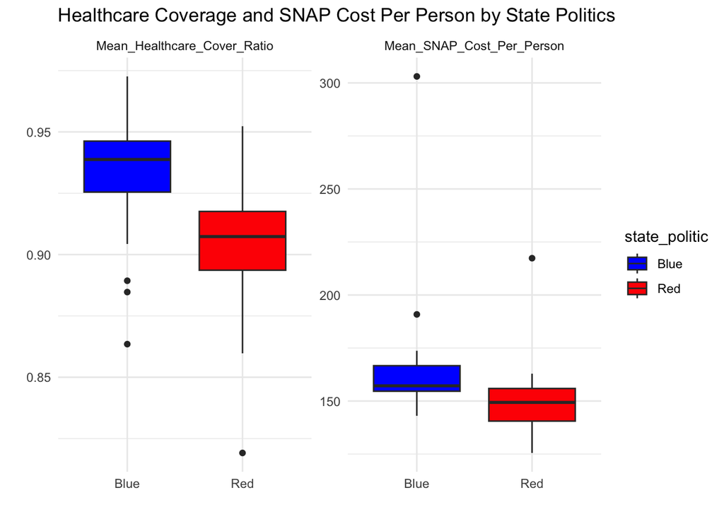

Once the outliers, specifically Alaska and Hawaii, were excluded, the data pattern became more discernible.

**Healthcare Coverage Ratio:** Blue states appear to have a higher median healthcare coverage ratio than Red states. The data for Blue states is more tightly clustered, indicating less variation in healthcare coverage ratios within these states. Red states show more variability, indicating some Red states with significantly lower healthcare coverage ratios.

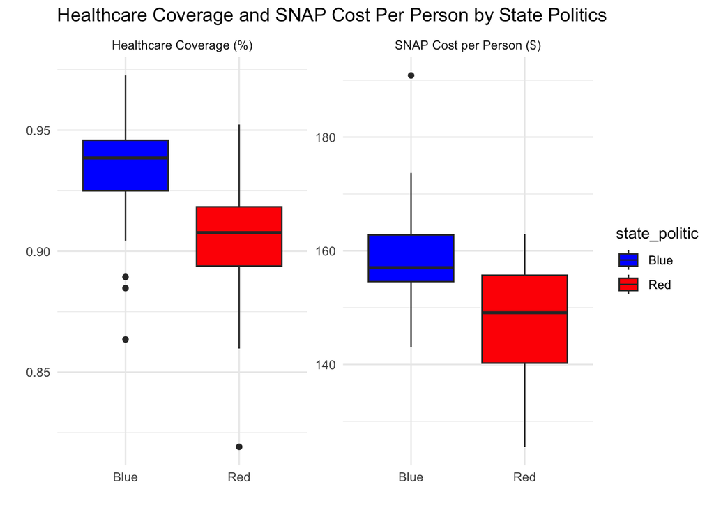

## Julia

**Research Question**  
Which racial group participates in the SNAP program the most amongst different states?

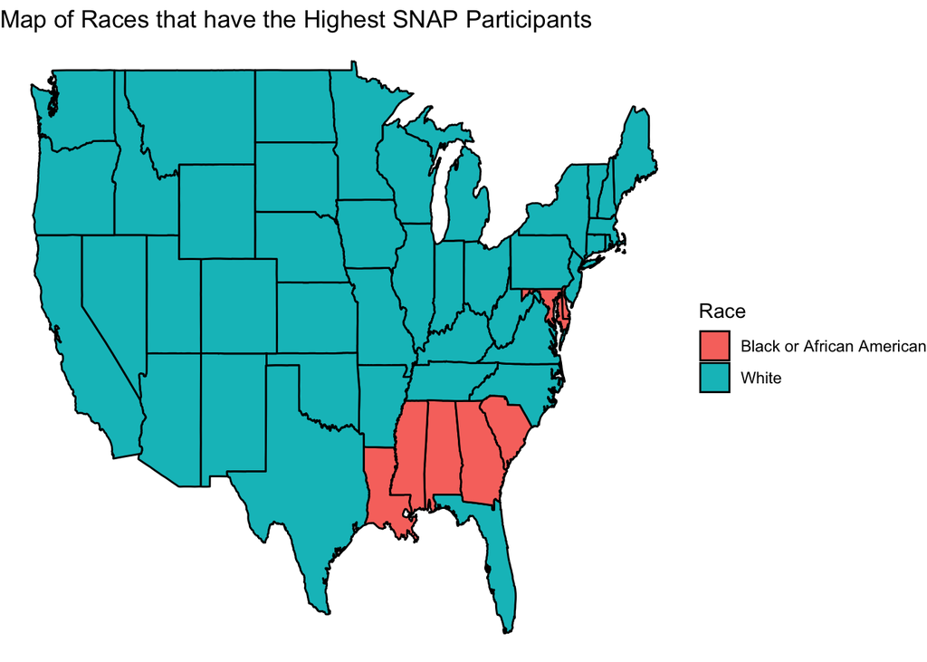

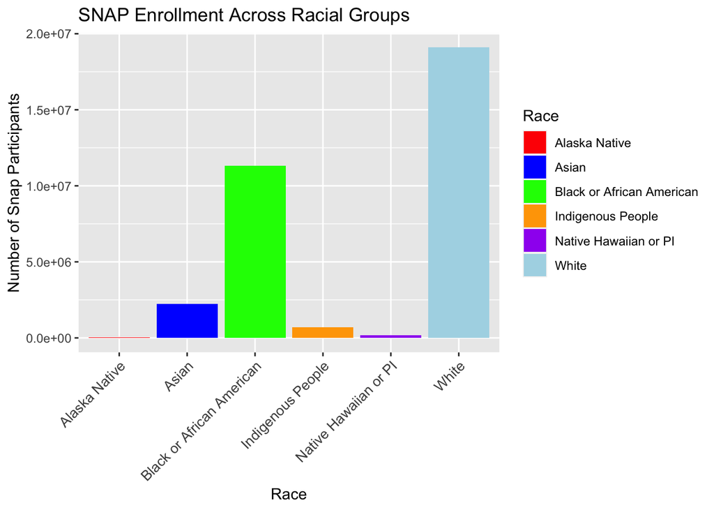

```r
#Bar Plotting
#Plotting a Bar plot to compare the race groups nationally
raceBar <- ggplot(sumSNAPbyRace) +
  geom_col(aes(x = Race, y = SumSNAPcount, fill = Race)) +
  scale_fill_manual(values = c("red", "blue", "green", "orange", "purple","lightblue")) +
  labs(title = "SNAP Enrollment Across Racial Groups",
       x = "Race",
       y = "Number of Snap Participants") +
  theme(axis.text.x = element_text(angle = 45, hjust = 1, size = 10))
print(raceBar)
```

## Angelic

**Research Question**

### Do states with the highest SNAP participation also reflect the highest healthcare coverage?

I am calculating the average individual SNAP participation for each state across all the years (2017-2022, missing 2020). Then, I am ranking the states based on average SNAP participation.

```r
average_snap_participation <- merged_data %>%
  group_by(State) %>%
  summarise(Average_SNAP_Participation = mean(`SNAP Persons Participation`, na.rm = TRUE))

head(average_snap_participation)
```

```
## # A tibble: 6 × 2
##   State      Average_SNAP_Participation
##   <chr>                           <dbl>
## 1 Alabama                       755904.
## 2 Alaska                         87840.
## 3 Arizona                       841978.
## 4 Arkansas                      352458.
## 5 California                   4082569.
## 6 Colorado                      471405.
```

```r
ranked_states <- average_snap_participation %>%
  arrange(desc(Average_SNAP_Participation)) %>%
  mutate(SNAP_Participation_Rank = rank(-Average_SNAP_Participation, na.last = "keep"))

ranked_states
```

```
## # A tibble: 51 × 3
##    State          Average_SNAP_Participation SNAP_Participation_Rank
##    <chr>                               <dbl>                   <dbl>
##  1 California                       4082569.                       1
##  2 Texas                            3624674.                       2
##  3 Florida                          3120150.                       3
##  4 New York                         2797646.                       4
##  5 Illinois                         1867617.                       5
##  6 Pennsylvania                     1786642.                       6
##  7 Georgia                          1553279.                       7
##  8 Ohio                             1436419.                       8
##  9 North Carolina                   1418802                        9
## 10 Michigan                         1291776.                      10
## # ℹ 41 more rows
```

Calculating the percentage of healthcare coverage for each state, and then computing the average healthcare coverage across all the years.

```r
healthcare_coverage <- merged_data %>%
  mutate(Healthcare_Coverage_Percentage = (`With health insurance coverage` / `Total(Healthcare)` * 100))

average_healthcare_coverage <- healthcare_coverage %>%
  group_by(State) %>%
  summarise(Average_Healthcare_Coverage_Percentage = mean(Healthcare_Coverage_Percentage, na.rm = TRUE))

head(average_healthcare_coverage)
```

```
## # A tibble: 6 × 2
##   State      Average_Healthcare_Coverage_Percentage
##   <chr>                                       <dbl>
## 1 Alabama                                      89.9
## 2 Alaska                                       88.2
## 3 Arizona                                      88.9
## 4 Arkansas                                     90.8
## 5 California                                   92.7
## 6 Colorado                                     92.1
```

Merging the dataset with SNAP Participation rank and the dataset with average healthcare coverage percentage.

```r
merged_SNAP_healthcare <- merge(average_healthcare_coverage, ranked_states, by = "State")

head(merged_SNAP_healthcare)
```

```
##        State Average_Healthcare_Coverage_Percentage Average_SNAP_Participation
## 1    Alabama                               89.87359                  755903.50
## 2     Alaska                               88.20954                   87840.33
## 3    Arizona                               88.93358                  841977.67
## 4   Arkansas                               90.82859                  352457.83
## 5 California                               92.70528                 4082568.67
## 6   Colorado                               92.14885                  471405.33
##   SNAP_Participation_Rank
## 1                      17
## 2                      46
## 3                      14
## 4                      33
## 5                       1
## 6                      27
```

I filtered out the top 10 ranked states (w.r.t. average SNAP participation) and created a bar graph that compare the rank to healthcare coverage percentage.

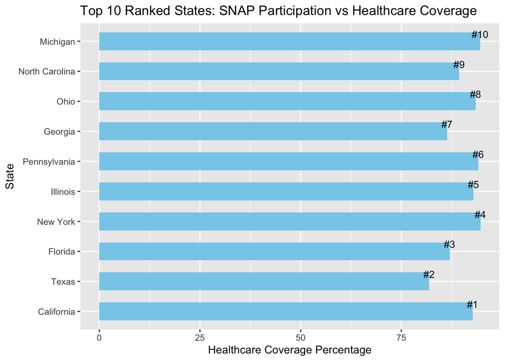

```r
top_10_states <- merged_SNAP_healthcare %>%
  filter(SNAP_Participation_Rank <= 10)

ggplot(top_10_states, aes(x = reorder(State, SNAP_Participation_Rank), y = Average_Healthcare_Coverage_Percentage)) +
  geom_bar(stat = "identity", fill = "skyblue",  width = 0.6) +
  geom_text(aes(label = paste0("#", SNAP_Participation_Rank)), vjust = -0.5, size = 3.5) +
  labs(x = "State", y = "Healthcare Coverage Percentage", title = "Top 10 Ranked States: SNAP Participation vs Healthcare Coverage") +
  coord_flip()
```

**The states were ranked by average SNAP participation across 5 years, with California having the highest participation at #1.**

I did the same thing but with the 10 worst ranked states (w.r.t. average SNAP participation).

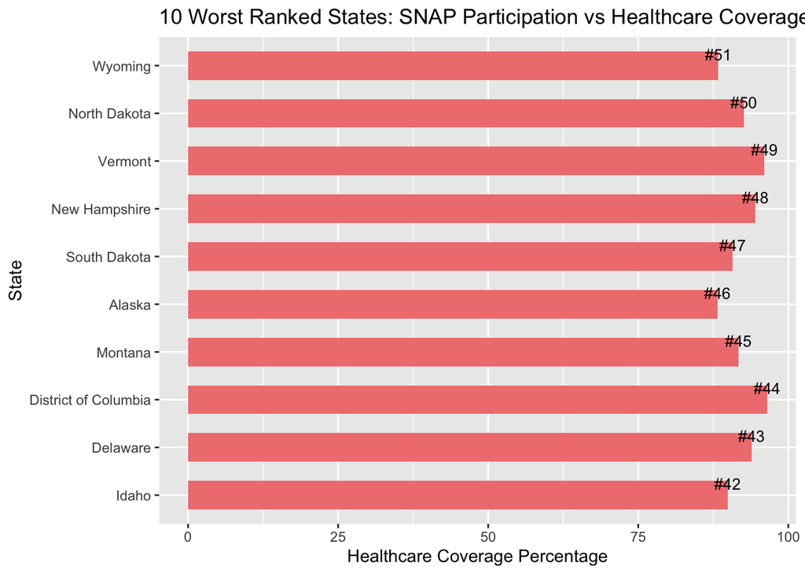

```r
worst_10_states <- merged_SNAP_healthcare %>%
  filter(SNAP_Participation_Rank > (nrow(merged_SNAP_healthcare) - 10))

ggplot(worst_10_states, aes(x = reorder(State, SNAP_Participation_Rank), y = Average_Healthcare_Coverage_Percentage)) +
  geom_bar(stat = "identity", fill = "lightcoral", width = 0.6) +
  geom_text(aes(label = paste0("#", SNAP_Participation_Rank)), vjust = -0.5, size = 3.5) +
  labs(x = "State", y = "Healthcare Coverage Percentage", title = "10 Worst Ranked States: SNAP Participation vs Healthcare Coverage") +
  coord_flip()
```

**Surprisingly, the 10 states with the lowest average SNAP participation seem to actually have higher overall healthcare coverage when compared to the 10 states with the highest average SNAP participation**